# Finanskrisen 2008

Fredrik Olsen, Anass Derraz and John Rejor Myran Øverås

## Unemployment ggplot

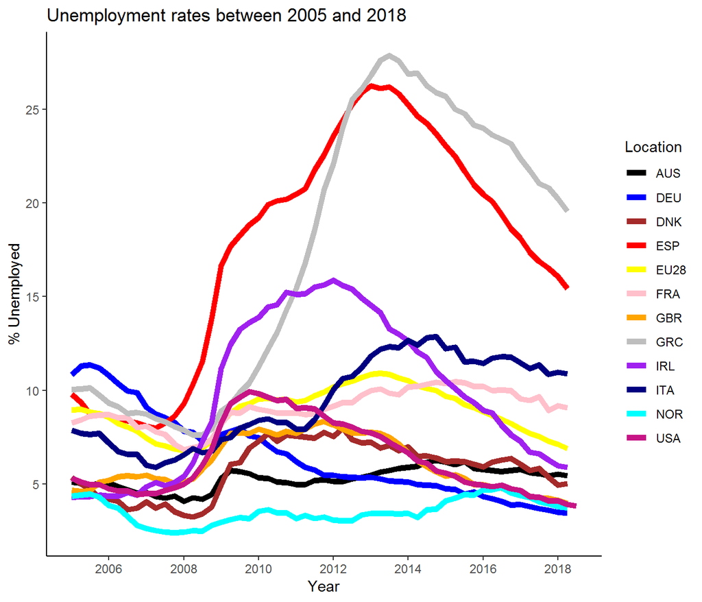

## Unemployment

I den første grafen, ser vi her på arbeidsledigheten. Her ser vi at det er stor variasjon i hvordan land ble påvirket av finanskrisen. Vi ser at land som: Hellas, Italia, Spania, Irland. Fikk store problemer etter finanskrisen, Irland sin krise varte ikke så lenge som de andre sin. Av disse landene ser vi også at Hellas desidert kom verst ut. Ser også at USA ble rimelig sterkt rammet av finanskrisen, men kom seg sterkere ut av det en EU generelt. Dette kan ha noe med at USA kjørte en mer mot-syklisk/Keynsiansk finans politikk. Ser også at sjokket traff Europa og EU litt senere en i USA. Ser også at Norge og Australia ikke ble rammet veldig hardt av finanskrisen, i forhold til veldig mange andre land.

## Government debt ggplot

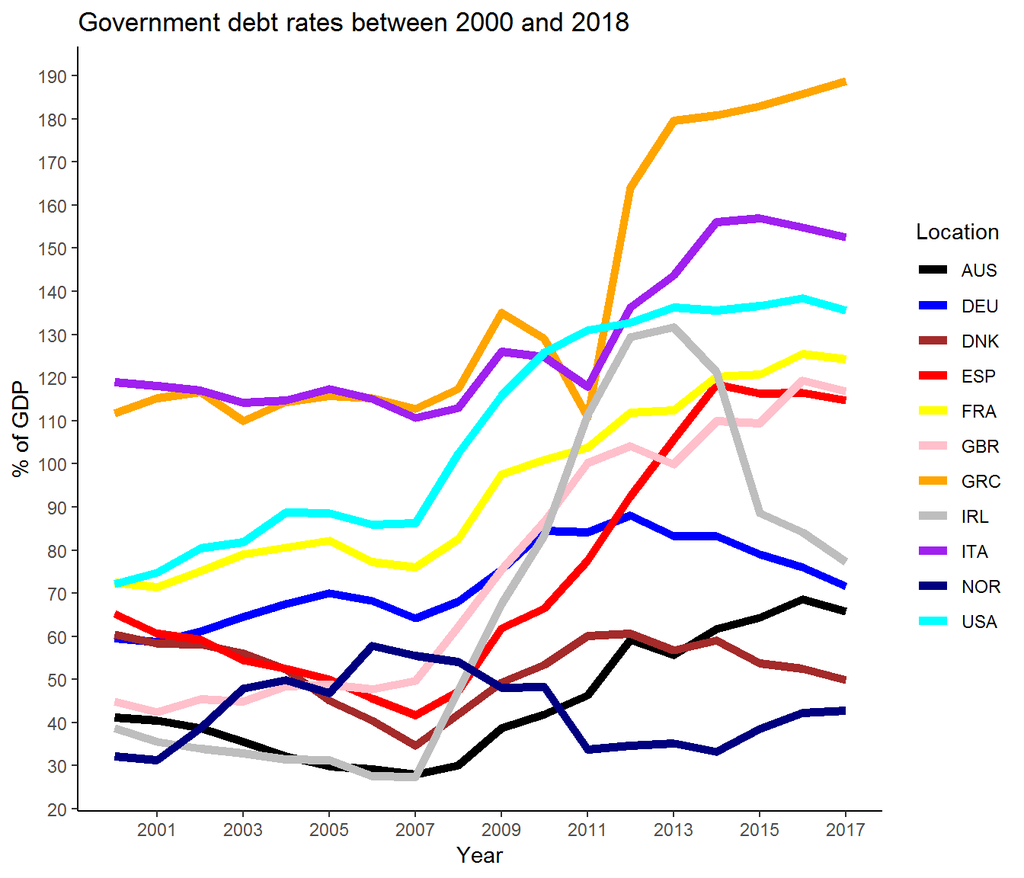